# 從重複抽樣到抽樣分布的形狀

Week 05 Part 1  
回到 Week 05 Index

HT3001B 生物統計學與 R

2026-10-08

## 重複抽樣：每份樣本各有平均數

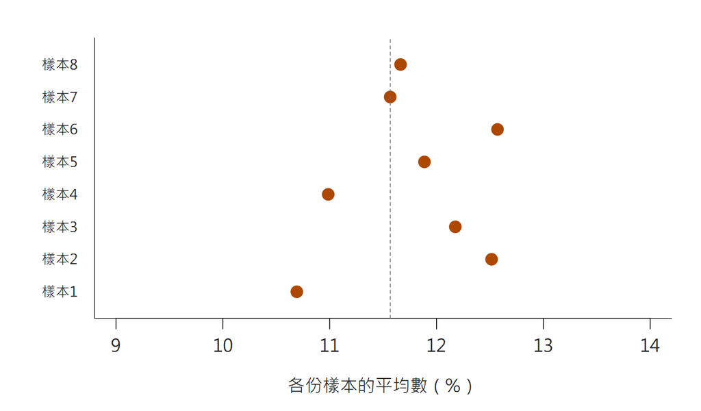

常態母體模型獨立抽出8份、每份50筆，各份平均不同；非真實貸款抽樣。

標準誤（standard error，SE）描述統計量在重複抽樣中的波動。

本課程自製模型示意；8份各50筆，seed=930；非貸款實測抽樣；IMS §13.3.2

## SD 與 SE 描述不同的分布

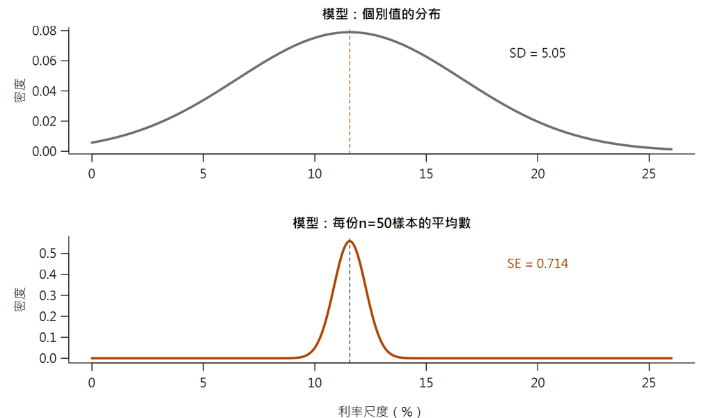

模型個別值分布SD5.05，n50均值抽樣分布SE0.714；上下橫軸一致、縱軸不同。

抽樣分布（sampling distribution）的標準差，就是 SE。

本課程自製模型示意；常態母體，σ=5.0521；非貸款擬合；兩圖縱軸刻度不同

## 線上模擬：從母體到抽樣分布

[**開啟抽樣分布模擬器 ↗**](https://audachang.github.io/biostats2026/week05/sampling_distribution.html)

由上到下，依序辨認三種分布：

| 面板 | 圖中的值代表什麼？ |
| --- | --- |
| 01 母體 | 抽樣來源的母體值 |
| 02 當次樣本 | 單次樣本的個別值（動畫顯示區） |
| 03 抽樣分布 A | 多次抽樣得到的樣本平均數 |

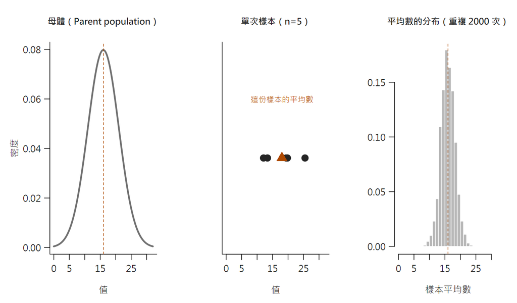

三張小圖由左到右：母體曲線；一份n等於5的樣本，橘色三角形是這份樣本的平均數；重複抽樣2000次得到的平均數分布。

本次使用 **平均數 Mean** 觀察平均數的 SE。

[本課程抽樣分布模擬器](https://audachang.github.io/biostats2026/week05/sampling_distribution.html)；互動設計參考 Online Statistics Education；圖為本課程自製示意（常態母體、n=5），非模擬器截圖

## 線上示範｜每份樣本只留一個平均數

[**開啟模擬器 ↗**](https://audachang.github.io/biostats2026/week05/sampling_distribution.html)

1. 母體選 **常態 Normal**；抽樣分布 A 選 **平均數、n=5**，B 先選 **不比較**。
2. 按 **清除下方三個面板**，再按 **抽樣 5 次**：抽 5 份、每份 5 筆，A 新增 5 個平均數。
3. 按 **抽樣 10,000 次** 累積更多平均數，觀察 A 的 **Reps** 與 **分布 SD**。

**n=5** 是每份樣本的筆數；**Reps** 是已重複抽樣的次數。

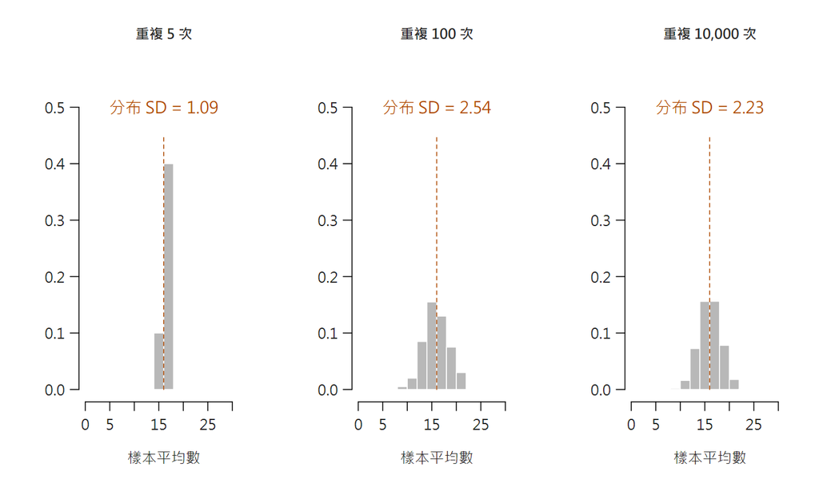

重複5次、100次、10000次的樣本平均數分布。次數愈多，分布愈穩定，分布SD分別約1.09、2.54、2.23。

抽樣分布 A 的每筆值是一份樣本平均數；它顯示的 **分布 SD** 估計平均數的 **SE**。

[本課程抽樣分布模擬器](https://audachang.github.io/biostats2026/week05/sampling_distribution.html)；圖為自製模型（常態母體，平均16、SD 5，seed=52），不是貸款或民調資料

## 機率：重複抽樣中的相對頻率

在模擬器中，每多抽一份樣本，就多一個平均數。重複次數（**Reps**）愈多，相對頻率愈穩定：

$$P(\text{事件}) \approx \frac{\text{事件發生的次數}}{\text{重複的總次數}}$$

- 機率（probability）：在無限次相同程序的重複中，事件發生的長期比例。
- 抽樣分布：統計量在重複抽樣中的機率分布。

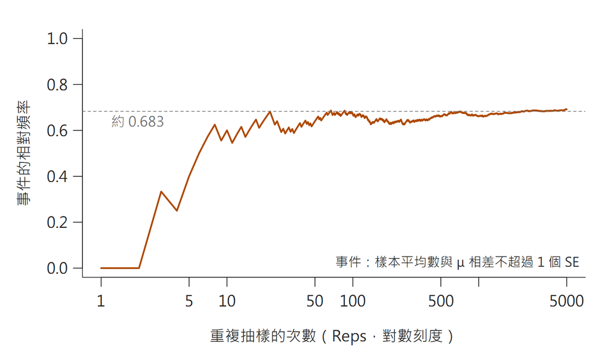

事件「樣本平均數與母體平均相差不超過1個SE」的相對頻率，隨重複次數增加，穩定在約0.683。

本課程整理與自製模擬（常態母體，n=5，5000次，seed=53）；[本課程抽樣分布模擬器](https://audachang.github.io/biostats2026/week05/sampling_distribution.html) 的 Reps 觀察

## 平均數的 SE 公式

獨立且同分配時：

$$\operatorname{SE}(\bar{x})=\frac{\sigma}{\sqrt n}$$

$$\widehat{\operatorname{SE}}(\bar{x})=\frac{s}{\sqrt n}$$

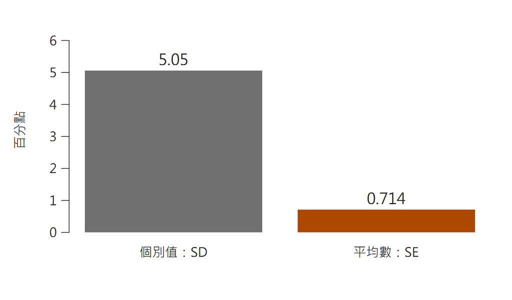

貸款利率SD5.05；以iid公式示範平均數SE0.714百分點。

貸款數值代入：$5.0521/\sqrt{50}\approx0.714$ 百分點。

IMS §13.3.2、Chapter 19 p.333；公式示範，未驗證loan50抽樣條件

## SE 隨樣本數改變

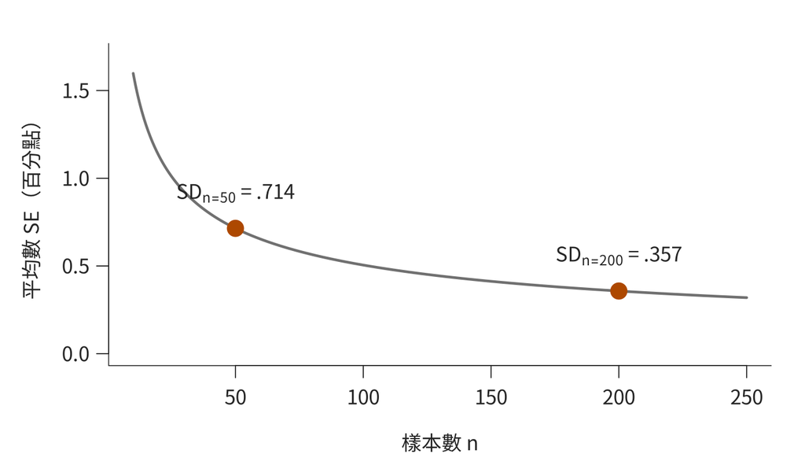

固定母體SD的iid模型中，樣本由50增為200，SE由0.714降至0.357。

同母體、相同抽樣條件：樣本數四倍，平均數 SE 減半。

本課程自製模型示意；固定σ；IMS §13.3.2、Chapter 19

## 線上比較｜樣本數四倍，SE 如何改變？

[**開啟模擬器 ↗**](https://audachang.github.io/biostats2026/week05/sampling_distribution.html)；母體維持 **常態 Normal**。

| 設定 | 抽樣分布 A | 抽樣分布 B |
| --- | --- | --- |
| 統計量 | 平均數 | 平均數 |
| 每份樣本筆數 | n=5 | n=20 |

按 **清除下方三個面板**，再按 **抽樣 10,000 次**。A、B 的 **分布 SD** 哪個較小？**母體 SD σ** 有改變嗎？

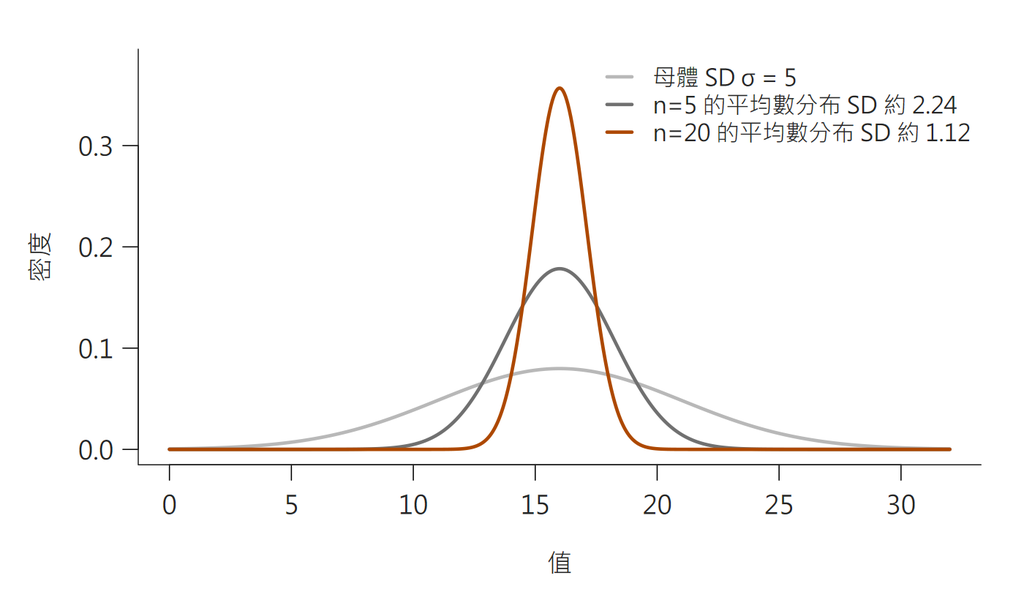

同一母體：母體SD為5，n等於5的平均數分布SD約2.24，n等於20的平均數分布SD約1.12；樣本愈大，曲線愈窄。

同母體：$\operatorname{SE}_{20}/\operatorname{SE}_{5}=\sqrt{5/20}=1/2$。

母體 SD 不變；平均數 SE 約減半。模擬結果有隨機波動，請比較顯示的分布 SD。

[本課程抽樣分布模擬器](https://audachang.github.io/biostats2026/week05/sampling_distribution.html)；同母體、獨立抽樣比較；σ/√n 理論關係；圖為自製理論曲線（母體平均16、SD 5）

## 民調：支持度是樣本比例

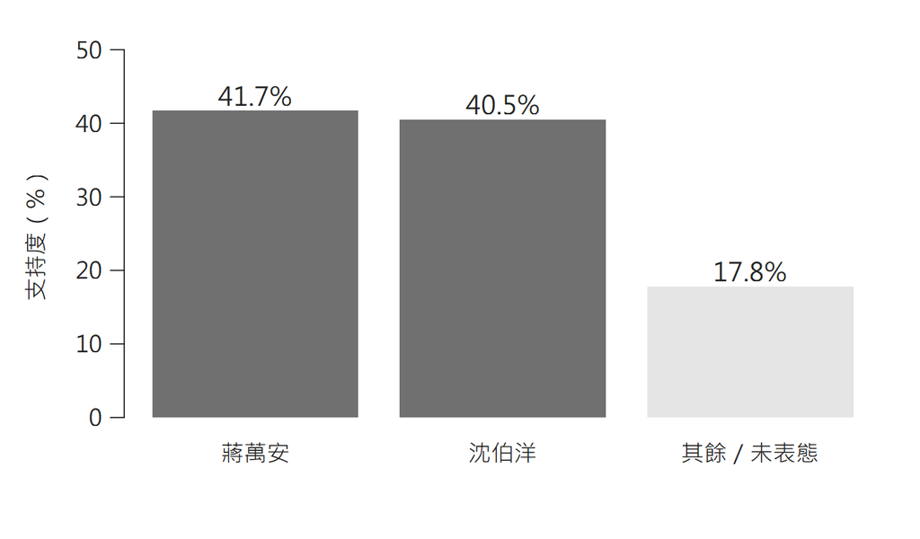

保存報導蔣41.7%、沈40.5%，其餘17.8%由差額推算。

樣本比例（sample proportion）$\hat p=0.417$，報導總樣本數 $n=1,076$。

保存民調紀錄；依報導轉述；2026-09-16至18訪問；其餘17.8%由差額推算

## 比例的 SE 公式

簡單獨立抽樣模型：

$$\widehat{\operatorname{SE}}(\hat p)=\sqrt{\frac{\hat p(1-\hat p)}{n}}$$

$\hat p=.417$、$n=1,076$：

SE $\approx0.0150$，即 **1.50 百分點**。

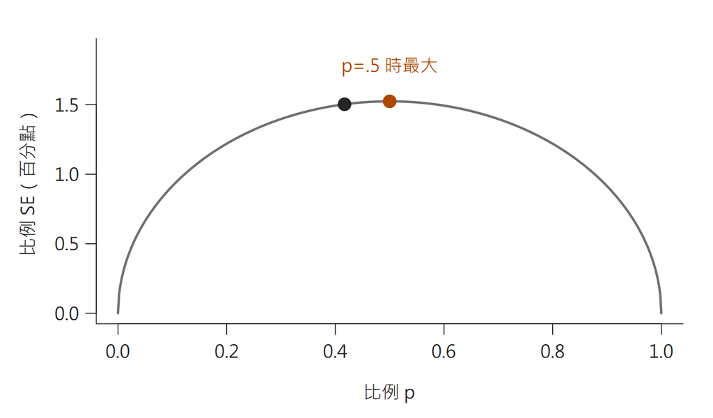

n1076簡單模型中，比例SE在p0.5最大，p.417的估計SE約1.50百分點。

IMS §16.2.1–16.2.2；保存民調紀錄；依報導轉述；簡單模型，非正式設計SE

## SE 與 95% 誤差範圍

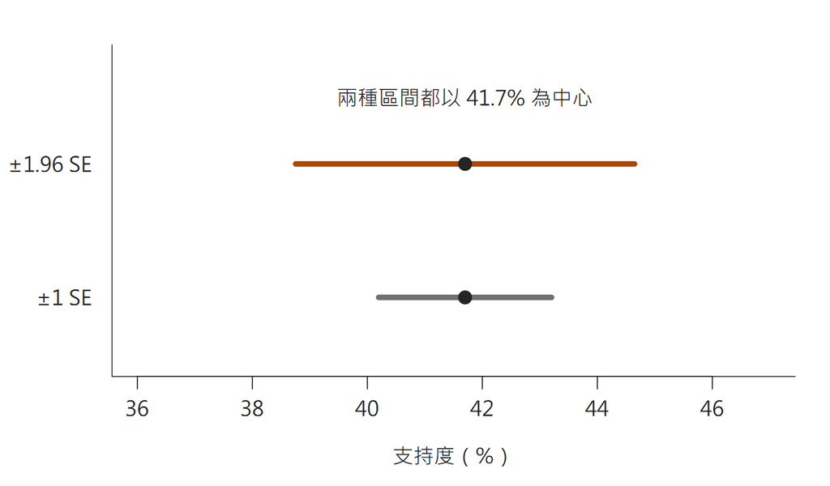

以41.7%為中心，±1SE較窄，常態近似±1.96SE較寬；簡單模型示意。

誤差範圍（margin of error）：95% 常態近似約為 $1.96\times\operatorname{SE}$。

IMS §13.3.2–13.3.3、§16.2；簡單模型，非正式民調區間

## 為什麼最大誤差約 ±3 百分點？

$p=.5$ 時，比例的變異最大。

$$\operatorname{SE}_{\max}=\sqrt{\frac{.5(1-.5)}{1,076}}$$

$$1.96\times0.01524\approx0.02988$$

| 簡單模型 | 百分點 |
| --- | --- |
| 最大 SE | 1.52 |
| 最大 95% 誤差範圍 | ±2.99 |

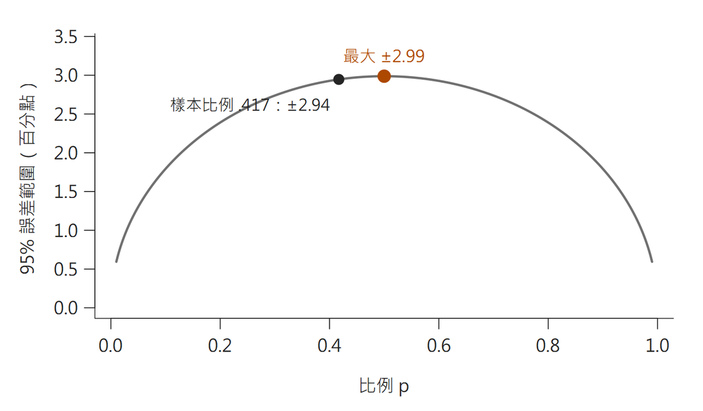

n等於1076時，95%誤差範圍隨比例p變化，呈拱形；p等於0.5時最大，約正負2.99百分點；p等於0.417時約2.94。

與報導 ±3.0 的數量級相近。實際分層、雙底冊與加權會影響 SE。

IMS §16.2；保存民調紀錄；依報導轉述；未取得原始報告，不重建正式設計估計；圖為本課程自製簡單模型

## 練習 1｜小樣本能沿用 ±3 嗎？

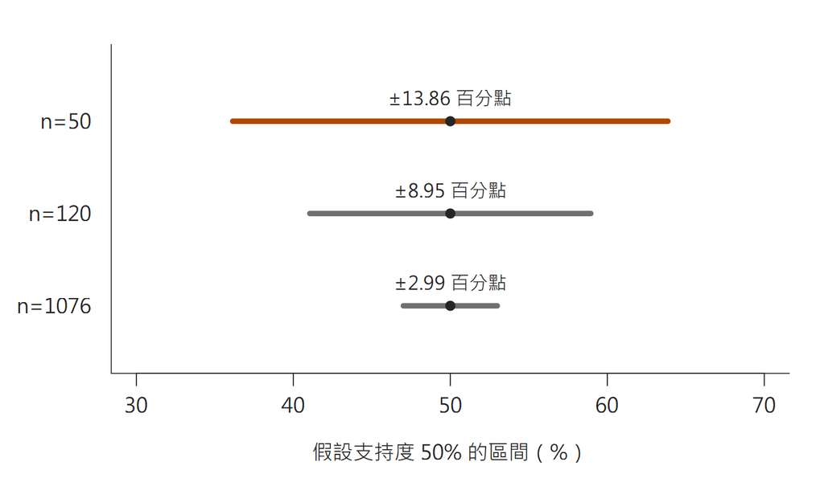

簡單模型p.5下，n1076最大誤差±2.99，n120±8.95，n50±13.86百分點。

行政區只有 120 或 50 人，能沿用全市的 ±3.0 百分點嗎？

不能。相同模型下樣本越少，誤差越大；圖中數值不是正式行政區設計估計。

本課程簡單模型示範，p=.5、95%常態近似；IMS §16.2

## 擲硬幣：相對頻率趨近機率

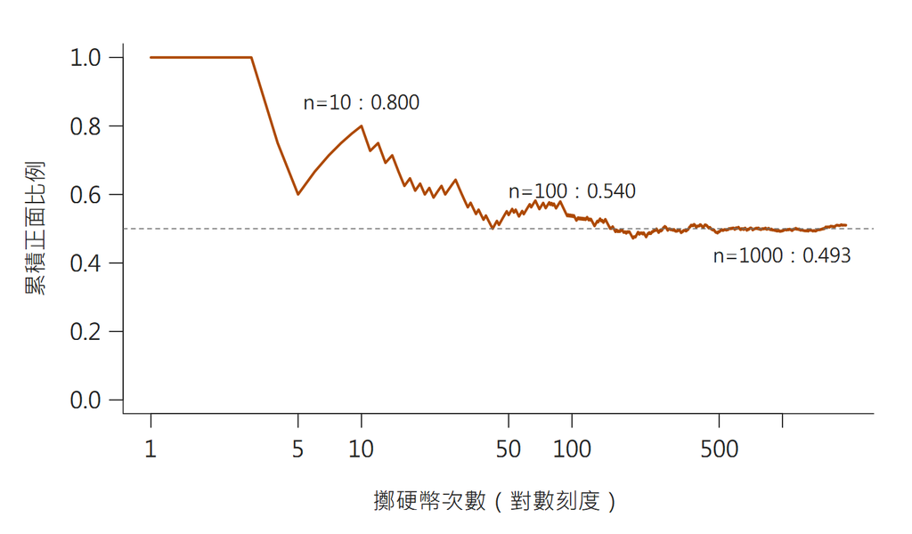

公平硬幣擲2000次的累積正面比例。擲10次時0.800，100次時0.540，1000次時0.493，逐漸靠近0.5。

累積擲硬幣的次數 $n$ 增加，正面比例趨近 $p=0.5$。

本課程自製模擬；公平硬幣，擲2000次，seed=54；橫軸為對數刻度

## 短期有波動，長期趨於穩定

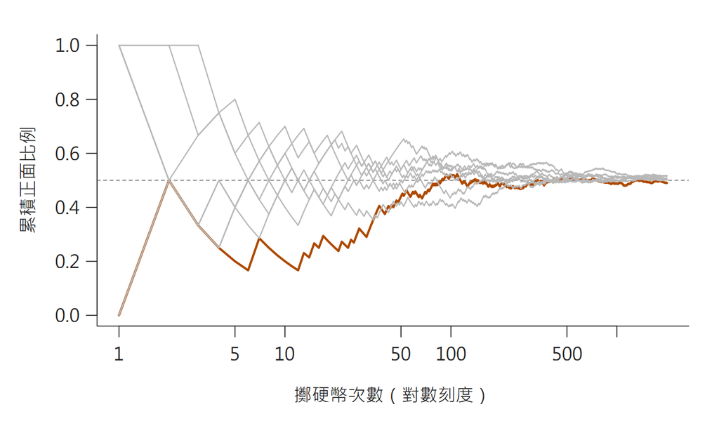

8次獨立的擲硬幣歷程。一開始各條線差異很大，次數愈多，都收斂到0.5附近；橘線是其中一次。

大數法則（law of large numbers）：累積觀察數 $n$ 增加，樣本平均數趨近母體平均數 $\mu$。

正面比例是 0／1 的平均；短期仍會波動，後面不會「補反面」。

本課程自製模擬；公平硬幣，8次歷程，各2000次，seed=61至68

## 互補事件

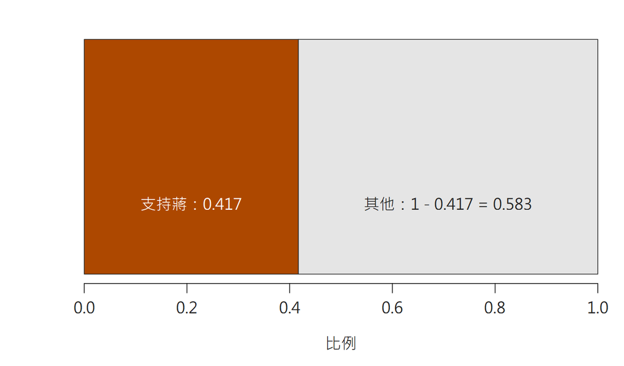

橫條分成兩段：支持蔣0.417，其他0.583，兩者相加為1。

事件 $A$ 沒有發生，稱為互補事件（complement）：$P(A^c)=1-P(A)$。

保存民調紀錄；樣本比例0.417，依報導轉述；圖為本課程自製

## 隨機變項：帶有隨機性的數值結果

隨機變項（random variable）$X$：結果帶有隨機性的數值。

情境：一位醫師讓 4 位高血壓病人試用新藥；假設每位病人血壓受控的機率為 0.7。

$X$ 是 4 位病人中受控的人數。

機率質量函數（probability mass function，pmf）列出每個可能值的機率；全部相加為 1。

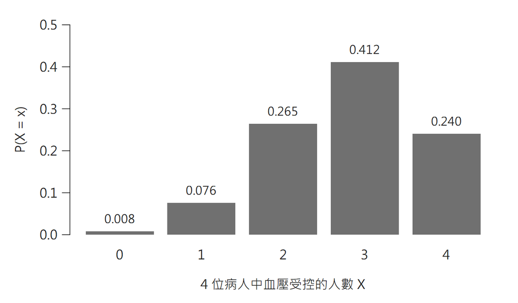

X等於0到4的機率長條圖：0.008、0.076、0.265、0.412、0.240；X等於3最可能。

Rosner §4.2–4.3，Example 4.4、4.6（Table 4.1）；課本直接列出各機率（X=3 為 .411），圖為本課程以二項分布 n=4、p=0.7 計算（.412）

## 期望值：長期平均

期望值（expected value）：

$$E(X)=\sum x\,P(X=x)$$

對應母體平均數 $\mu$。

本例 $E(X)=2.80$：長期平均每 4 位病人約有 2.8 位受控。

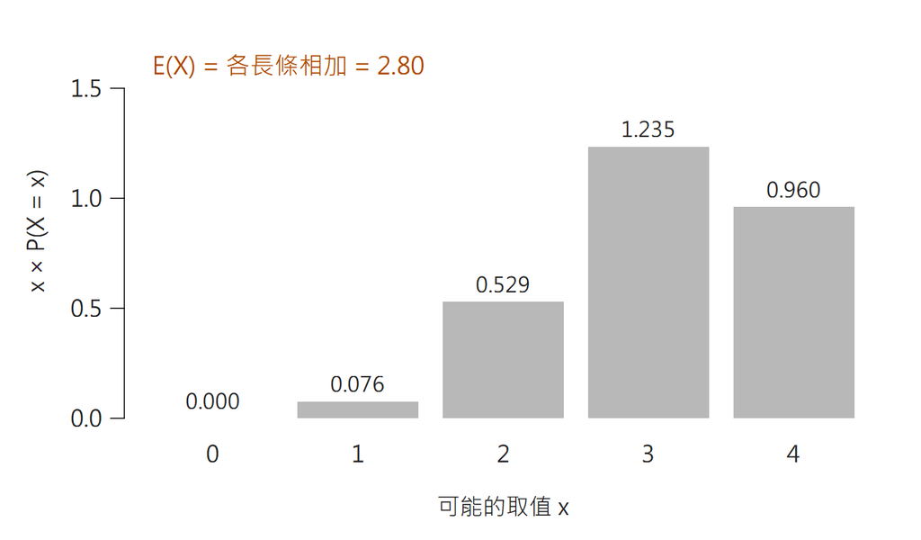

X等於0到4各自的x乘以機率：0、0.076、0.529、1.235、0.960，相加得2.80。

Rosner §4.4（課本算得 E(X)=2.80）；圖為本課程以二項分布 n=4、p=0.7 計算

## 變異數與二項分布

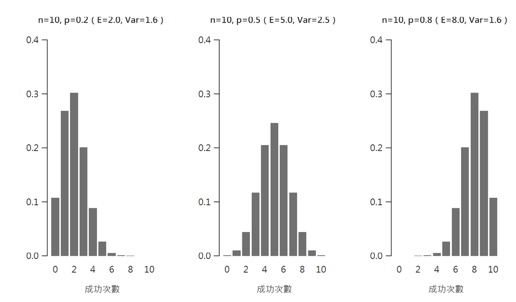

n等於10的三個二項分布：p等於0.2時偏右，p等於0.5時對稱，p等於0.8時偏左；變異數分別為1.6、2.5、1.6。

變異數（variance）：$\operatorname{Var}(X)=\sum (x-\mu)^2P(X=x)$。

二項分布（binomial distribution）：$n$ 次獨立試驗，每次成功機率 $p$；$E(X)=np$，$\operatorname{Var}(X)=npq$，其中 $q=1-p$。

Rosner §4.5、§4.8–4.9；圖為本課程自製（n=10）

## 證明｜二項分布的變異數

**① 一次試驗：成功記 1，失敗記 0**

$Y_i$ 服從伯努利分布（Bernoulli distribution）：$P(Y_i=1)=p$、$P(Y_i=0)=1-p$，$E(Y_i)=p$。

$$\operatorname{Var}(Y_i)=p(1-p)^2+(1-p)p^2=p(1-p).$$

**② n 次獨立試驗：成功總數是相加**

$X=\sum_{i=1}^{n}Y_i$，每次成功機率皆為 $p$，所以 $E(X)=np$。

獨立使交叉項為 0：$E[(Y_i-p)(Y_j-p)]=0$（$i\ne j$）。因此：

$$\operatorname{Var}(X)=E\!\left[\left(\sum_{i=1}^{n}(Y_i-p)\right)^2\right]=\sum_{i=1}^{n}\operatorname{Var}(Y_i)=\boxed{np(1-p)=npq}.$$

本課程推導；改寫自[伯努利與二項變異數補充教材](https://audachang.github.io/biostats2026/week04/week04_binary_variance_supplement.html)；前提：n 次試驗彼此獨立、成功機率相同；q=1−p

## 比例的 SE 從哪裡來

樣本比例 $\hat p=X/n$：

$$\operatorname{Var}(\hat p)=\frac{pq}{n}$$

$$\operatorname{SE}(\hat p)=\sqrt{\frac{pq}{n}}$$

與民調的比例 SE 公式相同。

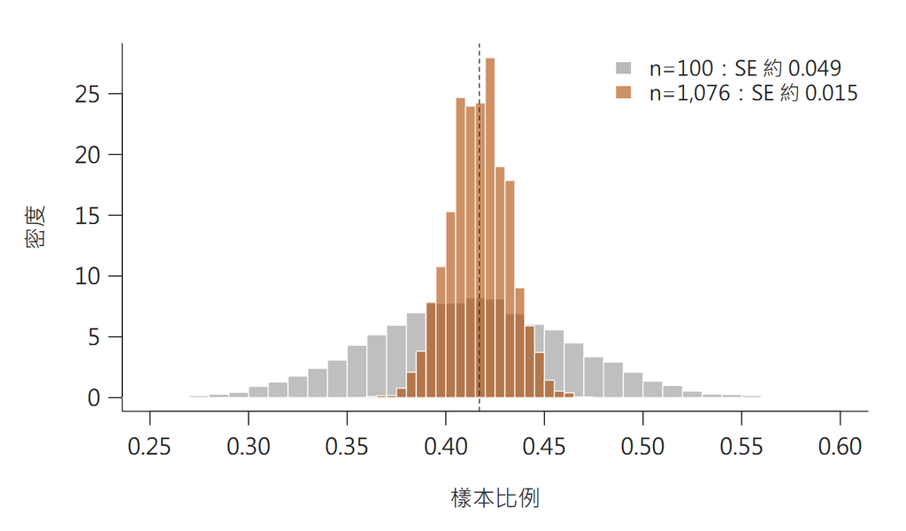

p等於0.417時，樣本比例的分布：n等於100較寬，SE約0.049；n等於1076較窄，SE約0.015。

IMS §16.2.1–16.2.2；Rosner §4.9；本課程自製模擬（各10,000次，seed=55）

## IQR：中央一半的寬度

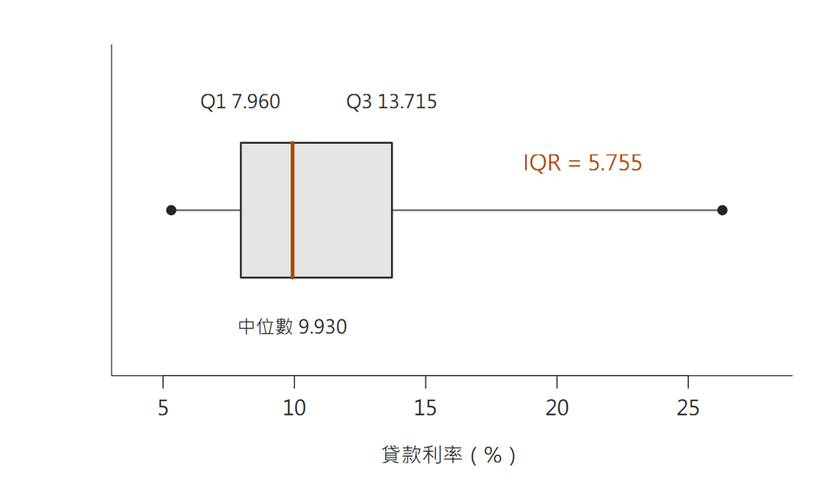

貸款利率Q1=7.960、中位數9.930、Q3=13.715%，IQR=5.755百分點。

四分位數（quartiles）；四分位距（interquartile range，IQR）$=Q_3-Q_1$。

[IMS 2e](https://openintrostat.github.io/ims/explore-numerical.html) §5.5；type=7；依Table5.3重繪；線段min至max，非鬚線

## 盒形圖與原始點圖

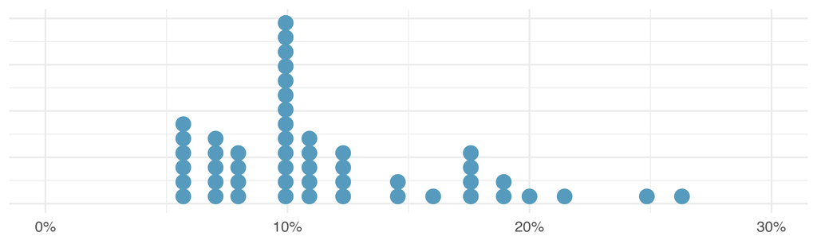

貸款利率原始點圖。

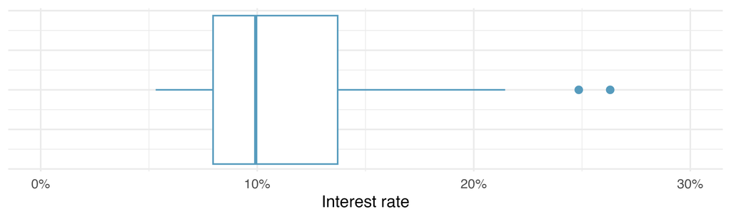

相同利率的盒形圖，盒內線為中位數，外側點為潛在離群點。

盒子從 Q1 到 Q3。外側點提示查核，不能直接判定錯誤。

[IMS 2e](https://openintrostat.github.io/ims/explore-numerical.html) §5.5；Figure 5.8(a)(b)（本機PDF Figure 5.9）

## 穩健性：只改一個極端值

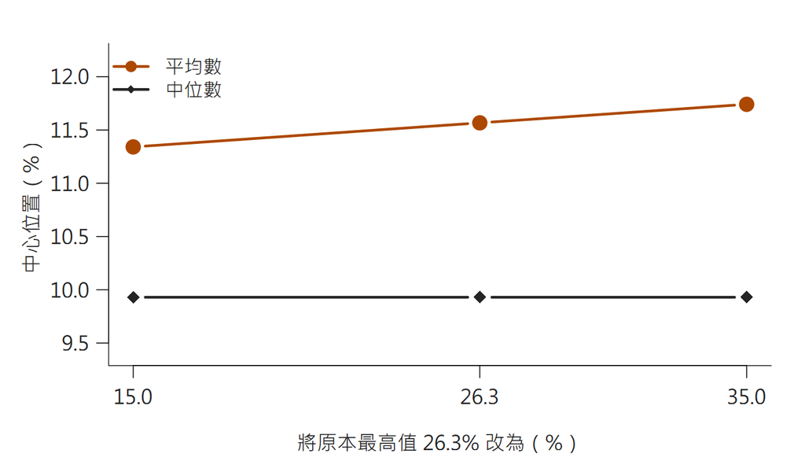

假想將26.3%改為15%或35%，均值改變而中位數在此例不變。

穩健統計量（robust statistic）較不易受少數極端值影響。

[IMS 2e](https://openintrostat.github.io/ims/explore-numerical.html) §5.6；Table5.4；本課程重算假想改值，原資料不變

## 課本的三種改值情境

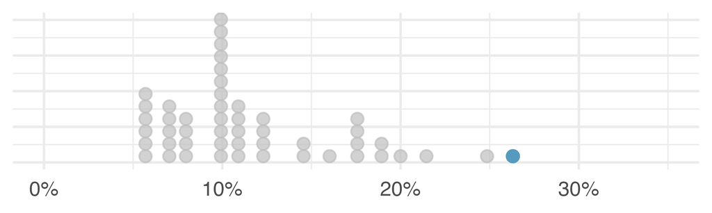

課本原始貸款利率點圖，最高26.3%。

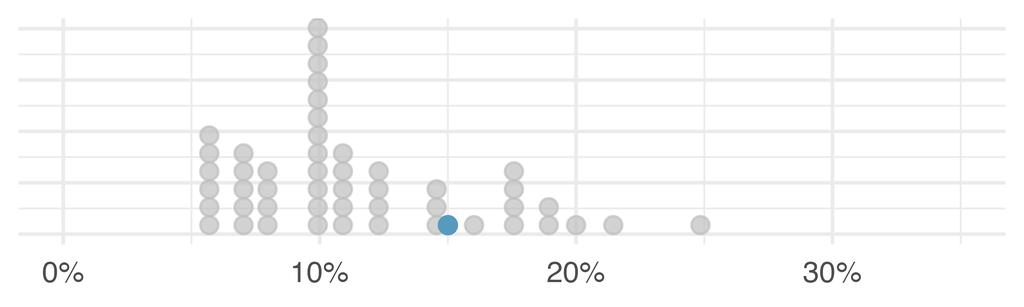

課本假想將26.3%改為15%的點圖。

原始 26.3% 與假想 15%。觀察尾端改變，中央位置保留。

[IMS 2e](https://openintrostat.github.io/ims/explore-numerical.html) §5.6；Figure 5.9(a)(b)（本機PDF Figure5.10）

## 極端值更大時，哪些量改變？

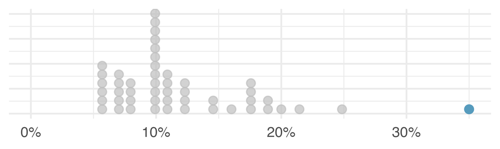

課本假想將最高利率26.3%改為35%的點圖。

| 最高值 | 平均數 | SD |
| --- | --- | --- |
| 15% | 11.34% | 4.61 |
| 26.3% | 11.57% | 5.05 |
| 35% | 11.74% | 5.68 |

三個情境：中位數 9.93%、IQR 5.755 百分點不變。

SD 單位：百分點。

[IMS 2e](https://openintrostat.github.io/ims/explore-numerical.html) §5.6；Figure5.9(c)、Table5.4；假想改值比較

## 練習 2｜所有值都加 1

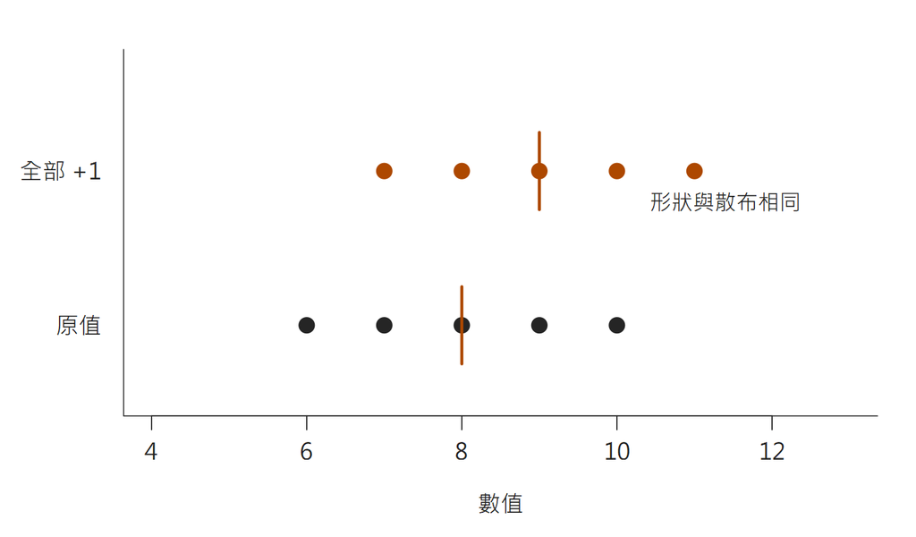

自編6至10全部加1後整體右移，散布不變。

平均數、SD 與同樣本數下的平均數 SE，分別如何改變？

平均數加 1。SD 不變，$s/\sqrt n$ 也不變。

本課程自編數值示範；IMS §5.2、§5.4；SE用iid公式

## 連續變項：面積才是機率

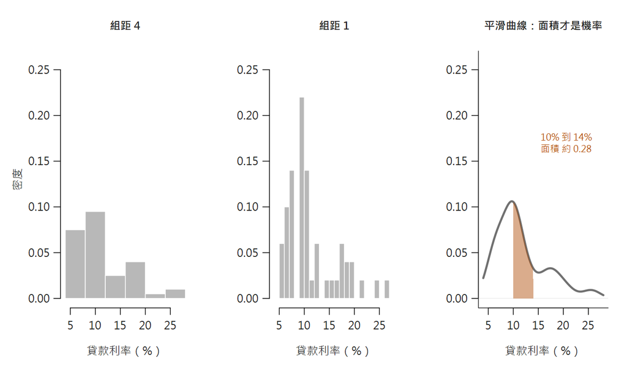

貸款利率三張圖：組距4的直方圖、組距1的直方圖、平滑曲線。曲線下10%到14%之間的橘色面積約0.28。

連續變項的機率是曲線下的面積；恰好等於某一個值的機率為 0。

資料：IMS loan50（Table 5.3 轉錄值，樣本非母體）；平滑曲線為本課程自製（bw=1.6）

## 常態分布與 z 分數

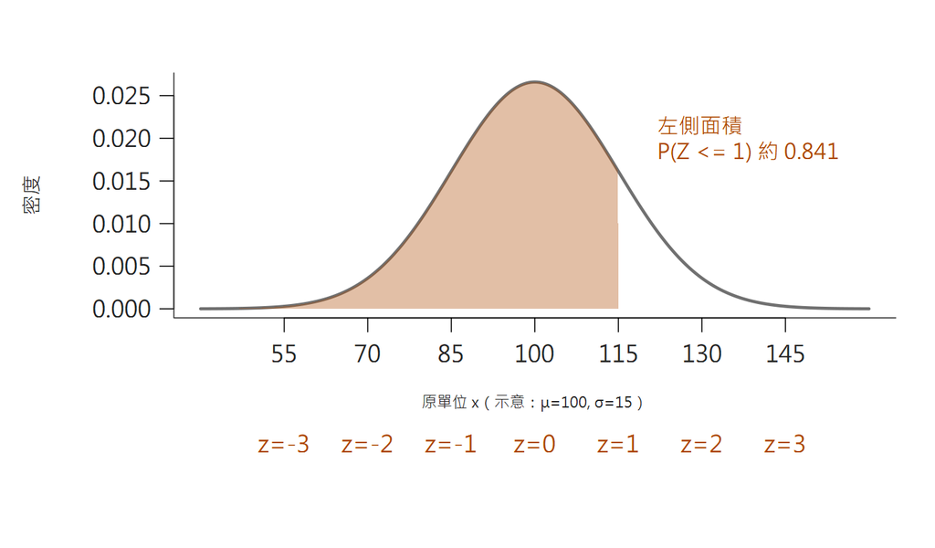

常態曲線：下方同時標出原單位（平均100、SD15）與z分數；x等於115即z等於1，左側面積約0.841。

常態分布（normal distribution）：$z=\dfrac{x-\mu}{\sigma}$ 表示離平均幾個標準差。

IMS §13.2.1–13.2.2；本課程自製示意（μ=100、σ=15）

## 68–95–99.7

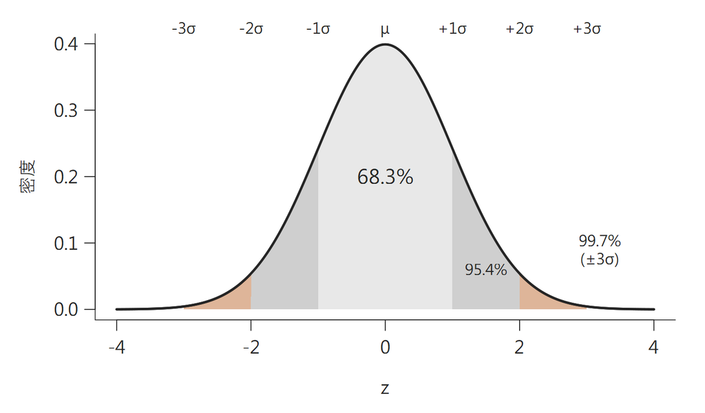

標準常態曲線：平均正負1個SD內約68.3%，正負2個SD內約95.4%，正負3個SD內約99.7%。

平均數正負 1、2、3 個標準差內，約有 68%、95%、99.7%。

IMS §13.3.1；本課程自製理論曲線